# MarioJFinal_Project

Mario Jayakumar

4/19/2018

# Analysis of IMDB5000 Movie Dataset

## Preface

The data that we are going to analyze is the TMDB5000, which can be [found here on kaggle](https://www.kaggle.com/tmdb/tmdb-movie-metadata/data). This dataset has almost 5000 rows containing information about different movies like budget, revenue, crew and much more. The reason that we are going to analyze this data set is to possibly predict the profit of a movie base on its different attributes. This could be used for checking the viability of a possible movie.

## Accessing and Viewing the Data

Once the data is downloaded, they can easily be read. They are both csv files so they can be read with read_csv.

```r
movie_data <- read_csv("data/tmdb_5000_movies.csv")
movie_credits <- read_csv("data/tmdb_5000_credits.csv")
```

The dataset actually contains two CSVs, one regarding the data about a movie, and the other regarding the credits data about the movie. You can view them like this:

```r
cat("Movies: \n ",attributes(movie_data)$names, sep = "\t")
```

```
## Movies:
##      budget  genres  homepage    id  keywords    original_language   original_title  overview    popularity  production_companies    production_countries    release_date    revenue runtime spoken_languages    status  tagline title   vote_average    vote_count
```

```r
cat("\n \n Credits: \n ",attributes(movie_credits)$names, sep = "\t")
```

```
##
##
##  Credits:
##      movie_id    title   cast    crew
```

Let’s create a histogram of budgets, so that we can see the distribution of budgets and what is the most common range. We draw a vertical red line at the median budget.

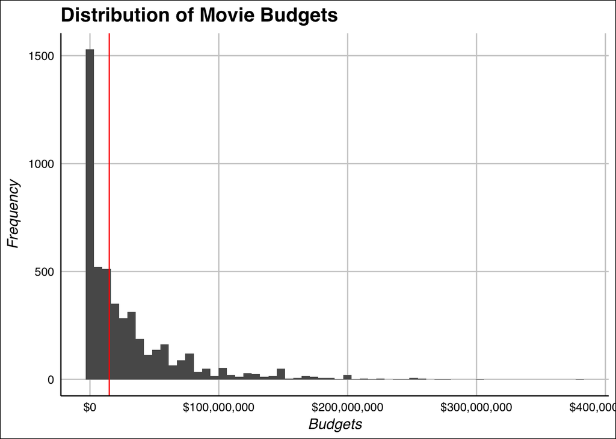

```r
movie_data %>%
  ggplot(aes(budget)) + geom_histogram(bins=60) +
  geom_vline(aes(xintercept=median(budget)), color="red") + ggtitle("Distribution of Movie Budgets") + xlab("Budgets") + ylab("Frequency") + scale_x_continuous(labels = scales::dollar) + theme_gdocs()
```

The distribution of budgets appears to be skewed right. We can see that there is a large amount of movies with a budget of 0, which is odd since movies cannot be made without a budget. We will then create a histogram filtering out the movies with a low budget, to get a more realistic idea of the spread. The low budgets recorded are most likely an error made when creating the data; a 30 million budget may have been written as 30, for example. Therefore it is safer to just remove all of the movies below a reasonable threshold.

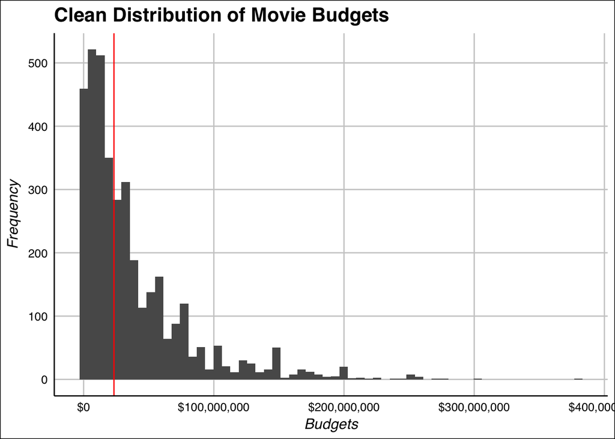

```r
movie_data %>%
  filter(budget > 5000) %>%
  ggplot(aes(budget)) + geom_histogram(bins=60) +
  geom_vline(aes(xintercept=median(budget)), color="red") + ggtitle("Clean Distribution of Movie Budgets") + xlab("Budgets") + ylab("Frequency") + scale_x_continuous(labels = scales::dollar) + theme_gdocs()
```

We can see that now the histogram is still skewed right, but is not dominated by zeros as much as before. This can be applied to revenue is well, since it is more than likely that the data is incorrect and should be removed, rather than the movie having made no money at all. We will filter out both of these cases from the data set. However we will only do this after extracting some more data from movie credits.

## Processing Multiple Datasets

Only picking necessary columns from movie_data so it is not so crowded. We will not be using these for the rest of the analysis.

```r
movie_data <- movie_data %>%
  select(budget,id,genres, original_title, popularity, production_companies, revenue, vote_average, keywords)
```

Each movie has its own unique ID to identify it. We can use this when working between the two datasets, since the movie name is not stored in credits. To start off our exploratory data analysis, we can compare directors and see which ones are the most successful. The only problem is, movie_data doesn’t have that as an attribute. Furthermore, movie_credit has it stored as a json within the crew attribute. The only way to get director is to then parse each json, and mutate that to the movie_data. Another reason we are doing this is because lots of attributes in both data sets are stored as JSONs, so we need to see how we can extract data when we need it.

```r
extract_director <- function(json) {
  #If the JSON is empty return NA for the director
  if (json == "[]") {
    return(NA)
  }
  else
  {
    #convert element from JSON to dataframe
    #filter for the director job and select the director name
    test <- fromJSON(json) %>%
      filter(job=="Director") %>%
      select(name)
    #nrow(test) yields 0 if director was not found
    if (nrow(test) == 0) {
      return(NA)
    }
    else {
      return(test$name[[1]])
    }
  }
}

#initializing an empty vector
director <- vector(mode="character",length = nrow(movie_credits))
#filling vectors with directors. Order is still maintained, so we can just add it on.
for (i in 1:nrow(movie_credits)){
  director[i] = extract_director(movie_credits$crew[i])
}

movie_data <- movie_data %>%
  mutate(directed = director)
```

Lets modify a ‘superhero’ attribute to each movie, where if it is a super hero movie we add a boolean value to it. We will use the same method used for directors to extract this value. The keywords attribute in movie_data has “superhero” if it is infact a superhero movie. This will be used to identify them.

```r
extract_superhero <- function(json) {
  if (json == "[]") {
    return(FALSE)
  }
  else
  {
    #filtering for the superhero keyword
    test <- fromJSON(json) %>%
      filter(name=="superhero")
    if (nrow(test) == 0) {
      return(FALSE)
    }
    else {
      return(TRUE)
    }
  }
}

superhero_list <- vector(mode="logical",length = nrow(movie_data))
for (i in 1:nrow(movie_data)){
  superhero_list[i] = extract_superhero(movie_data$keywords[i])

#mutating this to dataset
movie_data <- movie_data %>%
  mutate(is_superhero = superhero_list)
}
```

Now we extract genre. This is similar to all the other ones, except a movie can have multiple genres. We are only going to keep track of action, adventure, fantasy, scifi, drama and comedy. We will keep these on as logical attributes, so if a movie has multiple genres it will be true for those respective attributes.

```r
extract_genre <- function(json) {
  #if json empty then return false across all genres
  if (json == "[]") {
    return(c(FALSE, FALSE, FALSE, FALSE, FALSE, FALSE))
  }
  else
  {
    test <- fromJSON(json)
    action = FALSE
    adventure = FALSE
    fantasy = FALSE
    scifi = FALSE
    drama = FALSE
    comedy = FALSE
    #preparing tuple to return representing each genre
    if (nrow(test %>% filter(name=="Action")) > 0){ action = TRUE }
    if (nrow(test %>% filter(name=="Adventure"))  > 0){ adventure = TRUE }
    if (nrow(test %>% filter(name=="Fantasy")) > 0){ fantasy = TRUE }
    if (nrow(test %>% filter(name=="Science Fiction")) > 0){ scifi = TRUE }
    if (nrow(test %>% filter(name=="Drama")) > 0){ drama = TRUE }
    if (nrow(test %>% filter(name=="Comedy")) > 0){ comedy = TRUE }
    val = c(action, adventure, fantasy, scifi, drama, comedy)
    return(val)
  }
}

action_list <- vector(mode="logical",length = nrow(movie_data))
adventure_list <- vector(mode="logical",length = nrow(movie_data))
fantasy_list <- vector(mode="logical",length = nrow(movie_data))
scifi_list <- vector(mode="logical",length = nrow(movie_data))
drama_list <- vector(mode="logical",length = nrow(movie_data))
comedy_list <- vector(mode="logical",length = nrow(movie_data))
for (i in 1:nrow(movie_data)){
  #a tuple is returned of the form (action, adventure, fantasy, scifi, drama, comedy)
  temp = extract_genre(movie_data$genres[i])
  action_list[i] = temp[1]
  adventure_list[i] = temp[2]
  fantasy_list[i] = temp[3]
  scifi_list[i] = temp[4]
  drama_list[i] = temp[5]
  comedy_list[i] = temp[6]
}

#mutating these to our movie_data set
movie_data <- movie_data %>%
  mutate(action = action_list) %>%
  mutate(adventure = adventure_list) %>%
  mutate(fantasy = fantasy_list) %>%
  mutate(scifi = scifi_list) %>%
  mutate(drama = drama_list) %>%
  mutate(comedy = comedy_list)
```

## Cleaning the Data

We are done extracting all the data we want for our analysis, so we can begin to remove the unclean data. As a threshold, if a movie made less than or was made with less than $5000, it was most likely a mistake. In any case, it will not hurt our analysis.

```r
movie_data <- movie_data %>%
  filter(budget > 5000) %>%
  filter(revenue > 5000)
```

## Exploratory Data Analysis

The most interesting aspect of the movie data is how money much a movie made. While revenue indicates the gross income of the movie, we have to account for the budget of the movie. So we can mutate profit to the data set, which is $revenue - budget$.

```r
movie_data <- movie_data %>%
  mutate(profit = revenue - budget)
```

We also want to keep track of a logical analogy for the profit. Basically, if the profit was greater than 0, it was profitable. If not then the movie was not profitable. This will be useful when doing predictions later.

```r
movie_data <- movie_data %>%
  mutate(profitable = ifelse(profit > 0, TRUE, FALSE))
```

We can extract the proportion of profitable and unprofitable films using the summary method. First we group by profitability then we summarize by number of elements. We convert to matrix so that we can access elements via indices.

```r
summary_data <- movie_data %>%
  group_by(profitable) %>%
  summarize(num = n()) %>%
  ungroup()
summary_data <- as.matrix(summary_data)

profitable_trues <- summary_data[,2][2]
proportion <- (profitable_trues)/(profitable_trues + summary_data[,2][1])
cat("Proportion of Profitable Movies: ",proportion)
```

```
## Proportion of Profitable Movies:  0.7573209
```

From this we can see that about 75.7% of all movies are profitable.

Now we begin our exploratory data analysis. We first group by directors, so that we can perform analysis on each director. We then filter for the max profit movie for each director, and then ungroup the data. We can order the data in highest to lowest, then take the top 10 directors. After that, we rearrange the factors in reverse order so that when we plot it, it looks in order. Finally, we plot the data with labels. *ggrepel is used for the labels so it looks prettier*

[figure not shown]

```r
director_graph <- movie_data %>%
  group_by(directed) %>%
  filter(profit==max(profit)) %>%
  ungroup() %>%
  arrange(desc(profit)) %>%
  slice(1:10)

director_graph$directed <- factor(director_graph$directed, rev(as.character(director_graph$directed)))

director_graph %>%
  ggplot(aes(y=directed, x=revenue)) + geom_point() + ggtitle("Top 10 Highest Grossing Directors") + ylab("Director") + xlab("Profit") + scale_x_continuous(labels = scales::dollar) + geom_label_repel(aes(label=original_title)) + theme_gdocs()
```

Now we do some quick visualization on superhero and non-superhero movies. We can graph the distributions of profit for superhero and non-superhero movies. We use geom_violin to show distributions.

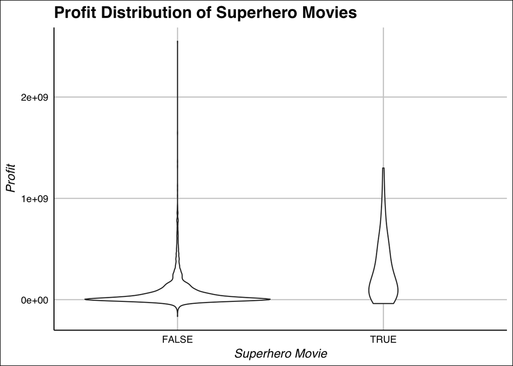

```r
movie_data %>%
  ggplot(aes(y=profit, x=is_superhero)) + geom_violin() + theme_gdocs() + ggtitle("Profit Distribution of Superhero Movies") + ylab("Profit") + xlab("Superhero Movie")
```

From this graph, we can see that both superhero and non-superhero films have a peak at about zero profit. However, superhero films seem to be less centered around zero, indicating that they are more profitable. However, it is unlikely that this will be useful for a predictor, since they are so close together.

We can now graph some aspects of genre. For each genre, we can do something similar to what we did for profit: create a distribution of profit for genre and “non-genre” films. Since we want to compare across genres, we place each graph in a grid so that they are easier to analyze.

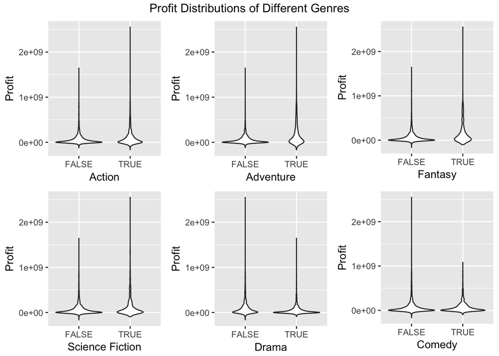

```r
p1 <- movie_data %>%
  ggplot(aes(x=action, y = profit)) + geom_violin()  + xlab("Action") + ylab("Profit")
p2 <- movie_data %>%
  ggplot(aes(x=adventure, y = profit)) + geom_violin()  + xlab("Adventure") + ylab("Profit")
p3 <- movie_data %>%
  ggplot(aes(x=fantasy, y = profit)) + geom_violin()  + xlab("Fantasy") + ylab("Profit")
p4 <- movie_data %>%
  ggplot(aes(x=scifi, y = profit)) + geom_violin()  + xlab("Science Fiction") + ylab("Profit")
p5 <- movie_data %>%
  ggplot(aes(x=drama, y = profit)) + geom_violin()  + xlab("Drama") + ylab("Profit")
p6 <- movie_data %>%
  ggplot(aes(x=comedy, y = profit)) + geom_violin()  + xlab("Comedy") + ylab("Profit")
grid.arrange(p1,p2,p3,p4,p5,p6, nrow=2, top = "Profit Distributions of Different Genres")
```

Just like superhero, almost all genres are centered around 0. Action, adventure and fantasy are all slightly spread apart from zero, but not significantly. Therefore, most of these will not be able to be used for a predictor.

To succinctly view what attributes of our data are useful for predicting profitability, we can use a density plot to compare them. The library caret has a function called featurePlot that allows us to create multiple density plot for certain features. More can be read about density plots [at this link](https://datavizcatalogue.com/methods/density_plot.html%5D) . For the density plot to work, we need the features to be numeric. That is, logicals like true and false must be converted to 1 or 0, where 1 represents true and 0 represents false. We also have to make our predicted variable, *profitable*, a factor of true and false. So first we select the attribute we want from the data frame, and then we convert them.

In our featurePlot function call there are many different arguments. x represents our different features that we want to plot. y represents the variable we are trying to predict, in this case profitability. The scales are used to make the graphs easier to read, since the lack of them would make the graphs very hard to interpret. PCH is the point used for plotting, so we use a simple “.” to represent points. Adjust changes the smoothness of the curves, where the higher the adjust value the more smooth each plot is. Finally, auto.key simply changes the aesthetics of the graph. More can be read about [feature plots here.](https://www.rdocumentation.org/packages/caret/versions/6.0-79/topics/featurePlot)

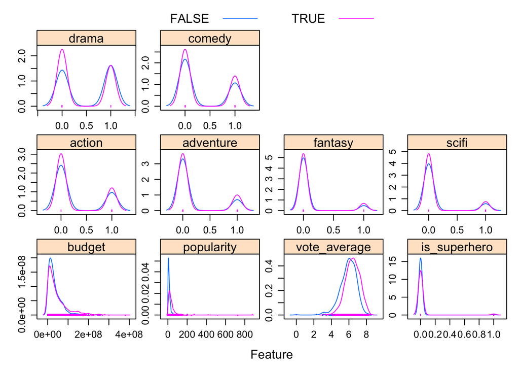

```r
final_set <- movie_data %>%
  select(-id, -genres, -original_title, -production_companies, -directed, -keywords, -revenue, -profit)
final_set$budget <- as.numeric(final_set$budget)
final_set$popularity <- as.numeric(final_set$popularity)
final_set$vote_average <- as.numeric(final_set$vote_average)
final_set$is_superhero <- as.numeric(final_set$is_superhero)
final_set$action <- as.numeric(final_set$action)
final_set$adventure <- as.numeric(final_set$adventure)
final_set$fantasy <- as.numeric(final_set$fantasy)
final_set$scifi <- as.numeric(final_set$scifi)
final_set$drama <- as.numeric(final_set$drama)
final_set$comedy <- as.numeric(final_set$comedy)
final_set$profitable <- as.factor(final_set$profitable)

featurePlot(x=final_set[,1:10], y=final_set$profitable, plot="density",
            scales = list(x = list(relation="free"), y = list(relation="free")),
            pch = ".",
            adjust = 1.1,
            layout = c(4, 3),
            auto.key = list(columns = 2, rows=2 , lines=TRUE))
```

Each graph represents the probability of success at a certain value. A peak means high probability at that specific value. Profitable and unprofitable are represented by different colors, but if we want features that distinguish them we want the peaks to occur at different values. If they peak for the same values, then that feature won’t be useful in predicting profitability, since it won’t be able to distinguish between profitable and unprofitable. Just like we expected, all the genres hve peaks at the same values so they won’t be useful in predicting. is_superhero also peaks at the same value, so it also won’t be useful. From this graph, we can see that budget and popularity can be useful for predicting profitability.

## Data Prediction

To create a decision tree we have to give it data to train on. We could give it our entire data set, but then we would have no way of testing it. If we train a certain model, it may be able to perfectly predict everything that it was trained for, but nothing outside that subset. Therefore we need to provide a testing set to evaluate our model, which we take out of our data set. This technique is called [cross validation.](https://towardsdatascience.com/cross-validation-in-machine-learning-72924a69872f) We partition our data set into 80% and 20%, where the larger partition is used for training.

```r
set.seed(1337)
prediction_set <- movie_data %>%
  select(-id, -genres, -original_title, -production_companies, -directed, -keywords, -revenue, -profit)
index <- createDataPartition(y=prediction_set$profitable, p=0.8, list=FALSE)

data_train <- prediction_set[index,]
data_test <- prediction_set[-index,]
```

```r
decision_tree <- rpart(profitable~budget+popularity, data=data_train, method="class")
predictions_decision <- predict(decision_tree, data_test)
predictions_decision <- factor(ifelse(predictions_decision[,2]>0.5, TRUE, FALSE))
data_test$profitable <- factor(data_test$profitable)
confusionMatrix(predictions_decision, data_test$profitable)
```

```
## Confusion Matrix and Statistics
##
##           Reference
## Prediction FALSE TRUE
##      FALSE    56   23
##      TRUE     99  463
##
##                Accuracy : 0.8097
##                  95% CI : (0.7771, 0.8394)
##     No Information Rate : 0.7582
##     P-Value [Acc > NIR] : 0.001072
##
##                   Kappa : 0.3769
##  Mcnemar's Test P-Value : 1.12e-11
##
##             Sensitivity : 0.36129
##             Specificity : 0.95267
##          Pos Pred Value : 0.70886
##          Neg Pred Value : 0.82384
##              Prevalence : 0.24181
##          Detection Rate : 0.08736
##    Detection Prevalence : 0.12324
##       Balanced Accuracy : 0.65698
##
##        'Positive' Class : FALSE
##
```

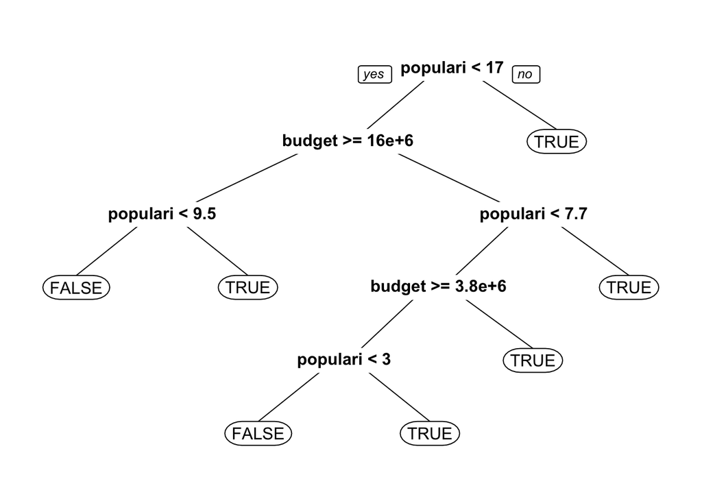

```r
prp(decision_tree)
```

Let’s see if we can improve that accuracy by using a different cross validation. We can now try a 10-fold cross validation. This involves splitting the data into k partitions, where we train on (k-1) partitions and test on 1 partition. We repeat this so that every partition is tested on once. This article further expands on how k-fold cross validation works and why it is done.

We are going to use caret to do this, so there are some variables we have to create first. We create train_control to define that we want a cross validation with 10 folds over the data. We then create the decision tree calling caret::train(). We define the entire prediction set into the method, along with the train control we defined. We also specify rpart as the method, so that we create a decision tree. The method requires the “y” value is a factor, so we factor it before we begin.

We also define tuneLength to be 10; tuneLength affects how long our tree will be built to, so we use a value that grows a tree similar to our last tree.

```r
prediction_set$profitable <- factor(prediction_set$profitable)
train_control <- trainControl(method="cv", number=10)
tree_fit <- train(profitable~budget+popularity, data=prediction_set, method="rpart", trControl=train_control, tuneLength=10)
tree_fit
```

```
## CART
##
## 3210 samples
##    2 predictor
##    2 classes: 'FALSE', 'TRUE'
##
## No pre-processing
## Resampling: Cross-Validated (10 fold)
## Summary of sample sizes: 2889, 2889, 2889, 2889, 2890, 2889, ...
## Resampling results across tuning parameters:
##
##   cp           Accuracy   Kappa
##   0.001283697  0.7728929  0.3221770
##   0.001711596  0.7797465  0.3333531
##   0.001925546  0.7806820  0.3332146
##   0.002246470  0.7822377  0.3358605
##   0.002567394  0.7878501  0.3483481
##   0.002995293  0.7922144  0.3488098
##   0.004706889  0.7940835  0.3377437
##   0.005134788  0.7950162  0.3388024
##   0.017329910  0.7919077  0.2905961
##   0.051775781  0.7691497  0.1228862
##
## Accuracy was used to select the optimal model using the largest value.
## The final value used for the model was cp = 0.005134788.
```

Our accuracy is now 79% which is unfortunately worse than we got before. We can plot the tree to see what it looks like.

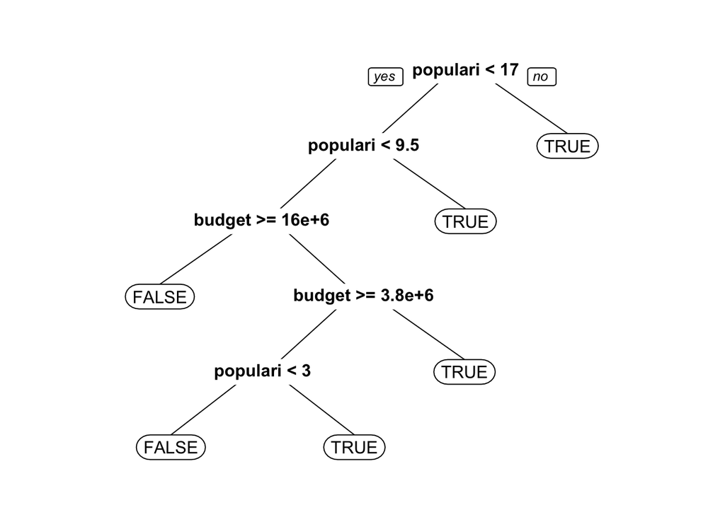

```r
prp(tree_fit$finalModel)
```

Another method we can try is random forests. A random forest is basically a bunch of decision trees merged together. Each tree is grown by selecting a random number of features, and then the average between trees is found. There is more information about [Random Forests here.](https://towardsdatascience.com/the-random-forest-algorithm-d457d499ffcd)

Creating this is very similar to the previous tree, since caret makes the steps much simpler. We send in all the features since the random forest will randomly pick them, and we use the same data set. We set our method to rf for random forests, and we use the same train control from the last set to do cross validation.

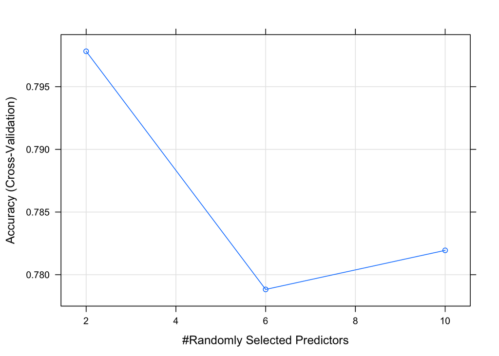

```r
forest_fit <- train(profitable~., data=prediction_set, method="rf", trControl=train_control)
plot(forest_fit)
```